# P8105_hw1_jr3869

# problem 1

Create a data frame comprised of:

A random sample of size 10 from a uniform[0, 5] distribution A logical vector indicating whether elements of the sample are greater than 2 A (length-10) character vector A (length-10) factor vector

```r
library(tidyverse)
set.seed(1)

vec_df = tibble(
  vec_data= runif(10, min=0, max=5),
  vec_logical = vec_data >2,
  vec_char = c("hello","world","my","name","is","Jingwei","Ren","a","b","c"),
  vec_factor=factor(c("male","male","female","female","d","e","f","g","h","i"))
)
```

### mean of each variable

```r
mean(vec_df$vec_data)
```

```
## [1] 2.757569
```

```r
mean(vec_df$vec_logical)
```

```
## [1] 0.6
```

```r
mean(vec_df$vec_char)
```

```
## [1] NA
```

```r
mean(vec_df$vec_factor)
```

```
## [1] NA
```

- mean function works for random sample and logical vector, but does not work for character and factor vector.This is because mean is only meaningful with numerical and logical vector.
- Write a code chunk that applies the as.numeric function to the logical, character, and factor variables (please show this chunk but not the output).

### convert to numeric part1

```r
as.numeric(vec_df$vec_logical)
as.numeric(vec_df$vec_char)
as.numeric(vec_df$vec_factor)
```

*Logical vector converts to 0 and 1.* Character vector gives warning:NAs introduced by coercion. *Factor vecter returns numeric numbers, which is based on the alphabetical orders in the sequence.

- In a second code chunk, convert your character variable from character to factor to numeric. similarly, convert your factor variable from factor to character to numeric.

### convert to numeric part2

```r
as.numeric(as.factor(vec_df$vec_char))
as.numeric(as.character(vec_df$vec_factor))
```

*Converting character variable from character to factor to numeric returns a vector of numeric numbers.* Converting factor variable from factor to character to numeric returns Warning: NAs introduced by coercion.

# problem 2

Create a data frame comprised of: x: a random sample of size 1000 from a standard Normal distribution y: a random sample of size 1000 from a standard Normal distribution A logical vector indicating whether the x + y > 0 A numeric vector created by coercing the above logical vector A factor vector created by coercing the above logical vector

### create a data frame

```r
set.seed(1)

plot_df = tibble(
  x=rnorm(1000),
  y=rnorm(1000),
  vec_logical= x+y >0,
  vec_numeric =as.numeric(vec_logical),
  vec_factor = as.factor(vec_logical)

)
```

- the size of the dataset is 1000 rows by 5 columns.
- The mean is -0.0116481
- The median is -0.0353242
- the proportion of cases for which the logical vector is true 0.49

### make a scatterplot

- Make a scatterplot of y vs x; color points using the logical variable

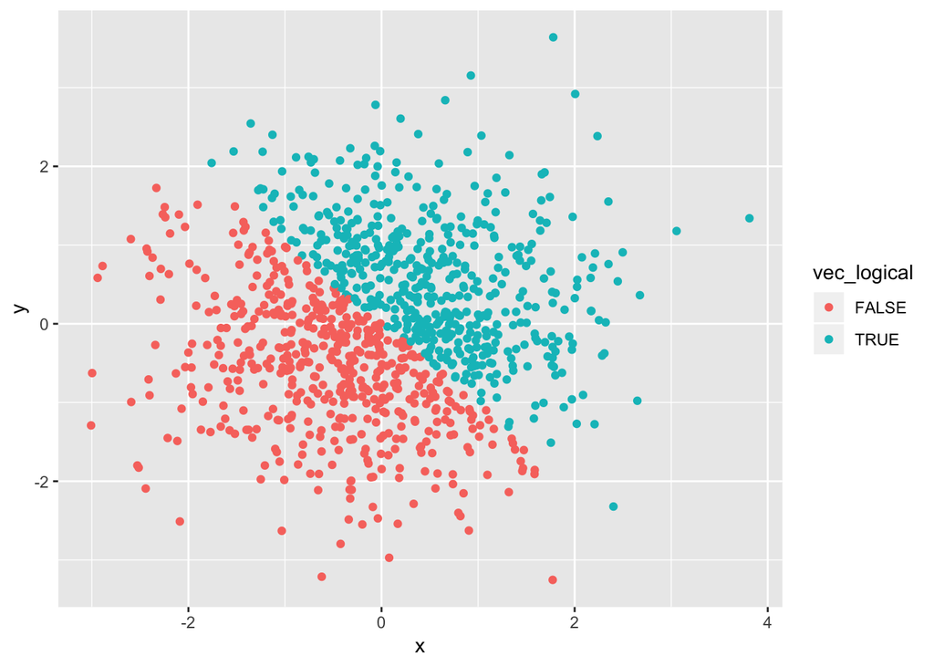

```r
library(tidyverse)

ggplot(plot_df, aes(x = x, y = y, color=vec_logical)) + geom_point()
```

```r
ggsave("scatter_plot1.pdf")
```

- In this case, x+y >0 is showing in blue and x+y <=0 is showing in red. Only two colors are in the color scale.
- Make a second and third scatterplot that color points using the numeric and factor variables

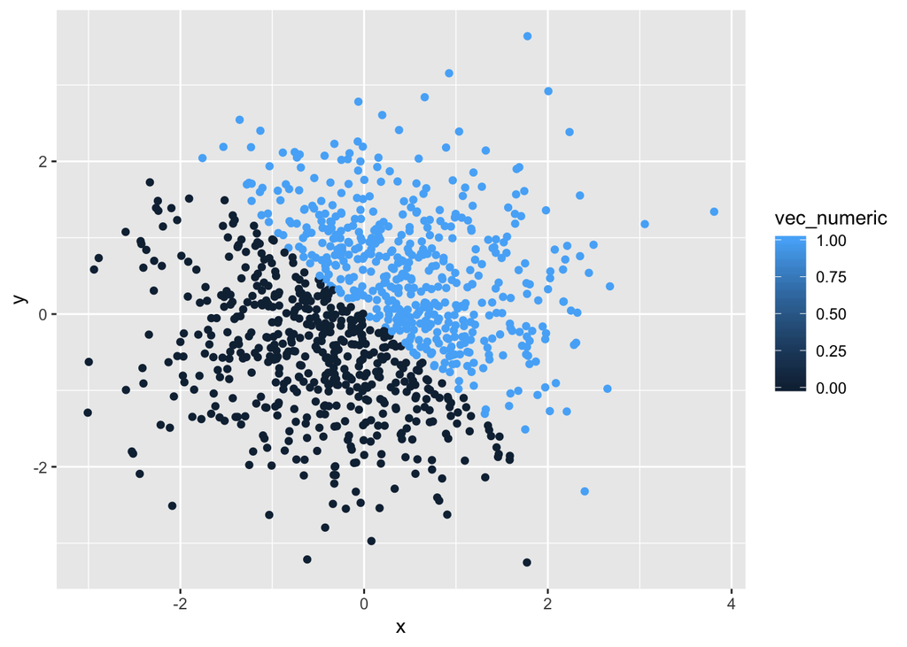

```r
library(tidyverse)

ggplot(plot_df, aes(x = x, y = y, color=vec_numeric)) + geom_point()
```

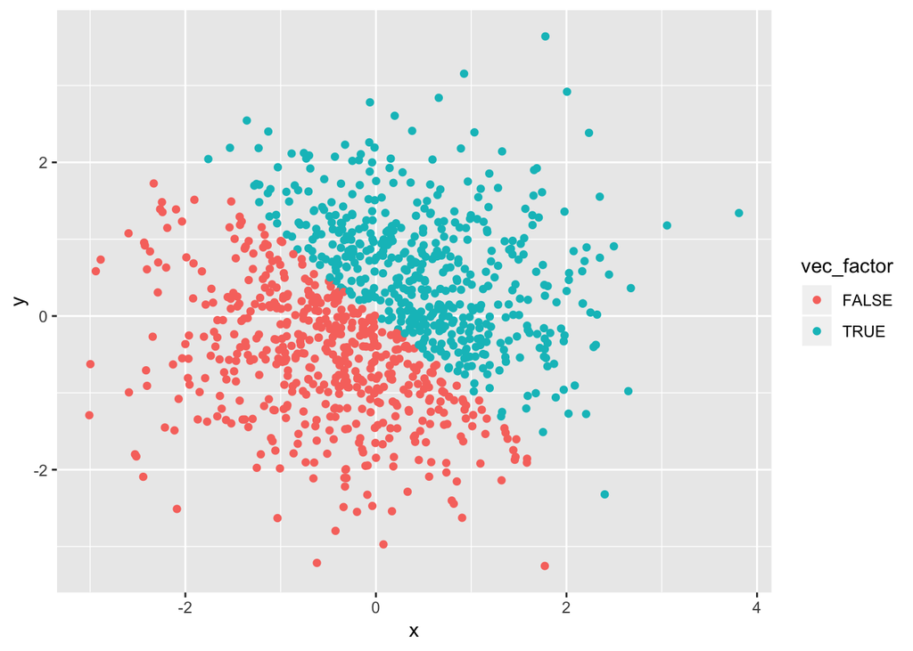

```r
ggplot(plot_df, aes(x = x, y = y, color=vec_factor)) + geom_point()
```

- In the second plot, the color scale uses a gradident, color changes from bright blue to dark blue as the sum of x,y deceases. Because there are only two different values in vec_numeric, only two colors are shown on the plot.
- In the third plot, x+y >0 is showing in blue and x+y <=0 is showing in red. Only two colors are in the color scale.